# Introduction to Julia

Biostat/Biomath M257

Author

Dr. Hua Zhou @ UCLA

Published

April 8, 2025

[figure not shown]

System information (for reproducibility)

```julia
versioninfo()
```

```
Julia Version 1.11.4
Commit 8561cc3d68d (2025-03-10 11:36 UTC)
Build Info:
  Official https://julialang.org/ release
Platform Info:
  OS: macOS (arm64-apple-darwin24.0.0)
  CPU: 12 × Apple M2 Max
  WORD_SIZE: 64
  LLVM: libLLVM-16.0.6 (ORCJIT, apple-m2)
Threads: 8 default, 0 interactive, 4 GC (on 8 virtual cores)
Environment:
  JULIA_NUM_THREADS = 8
  JULIA_EDITOR = code
```

Load packages:

```julia
using Pkg
Pkg.activate(pwd())
Pkg.instantiate()
Pkg.status()
```

```
  Activating project at `~/Documents/github.com/ucla-biostat-257/2025spring/slides/03-juliaintro`
```

```
Status `~/Documents/github.com/ucla-biostat-257/2025spring/slides/03-juliaintro/Project.toml`
  [6e4b80f9] BenchmarkTools v1.6.0
  [31c24e10] Distributions v0.25.118
  [6f49c342] RCall v0.14.6
  [37e2e46d] LinearAlgebra v1.11.0
  [9abbd945] Profile v1.11.0
  [2f01184e] SparseArrays v1.11.0
```

```julia
using BenchmarkTools, Distributions, RCall
using LinearAlgebra, Profile, SparseArrays
```

## 1 What’s Julia?

> Julia is a high-level, high-performance dynamic programming language for technical computing, with syntax that is familiar to users of other technical computing environments
- History:
  - Project started in 2009. First public release in 2012
  - Creators: Jeff Bezanson, Alan Edelman, Stefan Karpinski, Viral Shah
  - First major release v1.0 was released on Aug 8, 2018
  - Current stable release v1.11.4 (as of Apr 1, 2025)
- Aim to solve the notorious **two language problem**: Prototype code goes into high-level languages like R/Python, production code goes into low-level language like C/C++.

  Julia aims to:

> Walks like Python. Runs like C.

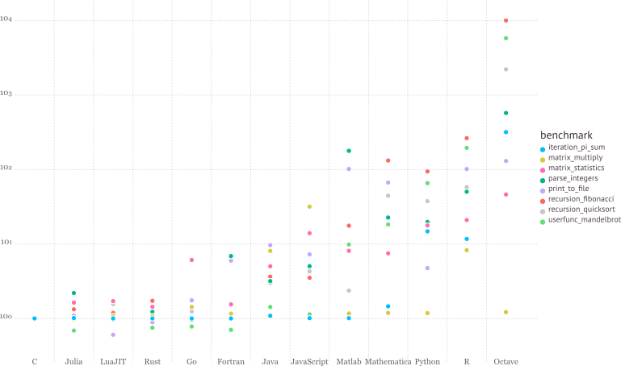

See https://julialang.org/benchmarks/ for the details of benchmark.

- Write high-level, abstract code that closely resembles mathematical formulas
  - yet produces fast, low-level machine code that has traditionally only been generated by static languages.
- Julia is more than just “Fast R” or “Fast Matlab”
  - Performance comes from features that work well together.
  - You can’t just take the magic dust that makes Julia fast and sprinkle it on [language of choice]

## 2 Learning resources

1. The (free) online course [Introduction to Julia](https://juliaacademy.com/p/intro-to-julia), by Jane Herriman.
2. Cheat sheet: [The Fast Track to Julia](https://juliadocs.github.io/Julia-Cheat-Sheet/).
3. Browse the Julia [documentation](https://docs.julialang.org/en).
4. For Matlab users, read [Noteworthy Differences From Matlab](https://docs.julialang.org/en/v1/manual/noteworthy-differences/#Noteworthy-differences-from-MATLAB-1).

   For R users, read [Noteworthy Differences From R](https://docs.julialang.org/en/v1/manual/noteworthy-differences/#Noteworthy-differences-from-R-1).

   For Python users, read [Noteworthy Differences From Python](https://docs.julialang.org/en/v1/manual/noteworthy-differences/?highlight=matlab#Noteworthy-differences-from-Python-1).
5. The [Learning page](http://julialang.org/learning/) on Julia’s website has pointers to many other learning resources.

## 3 Julia REPL (Read-Evaluation-Print-Loop)

The `Julia` REPL, or `Julia` shell, has at least five modes.

1. **Default mode** is the Julian prompt `julia>`. Type backspace in other modes to enter default mode.
2. **Help mode** `help?>`. Type `?` to enter help mode. `?search_term` does a fuzzy search for `search_term`.
3. **Shell mode** `shell>`. Type `;` to enter shell mode.
4. **Package mode** `(@v1.11) pkg>`. Type `]` to enter package mode for managing Julia packages (install, uninstall, update, …).
5. **Search mode** `(reverse-i-search)`. Press `ctrl+R` to enter search model.
6. With `RCall.jl` package installed, we can enter the **R mode** by typing `$` (shift+4) at Julia REPL.

Some survival commands in Julia REPL:

1. `exit()` or `Ctrl+D`: exit Julia.
2. `Ctrl+C`: interrupt execution.
3. `Ctrl+L`: clear screen.
4. Append `;` (semi-colon) to suppress displaying output from a command. Same as Matlab.
5. `include("filename.jl")` to source a Julia code file.

## 4 Seek help

- Online help from REPL: `?function_name`.
- Google.
- Julia documentation: https://docs.julialang.org/en/.
- Look up source code: `@edit sin(π)`.
- Discourse: https://discourse.julialang.org.
- Friends.

## 5 Which IDE?

- Many choices: VS Code, Vim, …
- For dynamic document, e.g., homework, I recommend [JupyterLab](http://jupyterlab.readthedocs.io/en/stable/) or VS Code (with Jupyter extension).
- For extensive Julia coding, myself has been happily using [VS Code](https://code.visualstudio.com) with extensions `Julia` and `VS Code Jupyter Notebook Previewer` installed.

## 6 Julia package system

- Each Julia package is a Git repository. Each Julia package name ends with `.jl`. E.g., `Distributions.jl` package lives at https://github.com/JuliaStats/Distributions.jl.  
  Google search with `PackageName.jl` usually leads to the package on github.com.
- The package ecosystem is rapidly maturing; a complete list of **registered** packages (which are required to have a certain level of testing and documentation) is at http://pkg.julialang.org/.
- For example, the package called `Distributions.jl` is added with

```julia
# in Pkg mode
(@v1.11) pkg> add Distributions
```

and “removed” (although not completely deleted) with

```julia
# in Pkg mode
(@v1.11) pkg> rm Distributions
```

- The package manager provides a dependency solver that determines which packages are actually required to be installed.
- **Non-registered** packages are added by cloning the relevant Git repository. E.g.,

```julia
# in Pkg mode
(@v1.11) pkg> add https://github.com/OpenMendel/SnpArrays.jl
```

- A package needs only be added once, at which point it is downloaded into your local `.julia/packages` directory in your home directory.

```julia
readdir(Sys.islinux() ? ENV["JULIA_PATH"] * "/pkg/packages" : ENV["HOME"] * "/.julia/packages")
```

```
803-element Vector{String}:
 "ADTypes"
 "AMD"
 "ANSIColoredPrinters"
 "ASL_jll"
 "AbstractAlgebra"
 "AbstractFFTs"
 "AbstractLattices"
 "AbstractTrees"
 "Accessors"
 "AccurateArithmetic"
 "Adapt"
 "AdaptivePredicates"
 "AlgebraicMultigrid"
 ⋮
 "libinput_jll"
 "libpng_jll"
 "libsass_jll"
 "libsixel_jll"
 "libsodium_jll"
 "libvorbis_jll"
 "libwebp_jll"
 "mtdev_jll"
 "oneTBB_jll"
 "x264_jll"
 "x265_jll"
 "xkbcommon_jll"
```

- Directory of a specific package can be queried by `pathof()`:

```julia
pathof(Distributions)
```

```
"/Users/huazhou/.julia/packages/Distributions/fi8Qd/src/Distributions.jl"
```

- If you start having problems with packages that seem to be unsolvable, you may try just deleting your .julia directory and reinstalling all your packages.
- Periodically, one should run `update` in Pkg mode, which checks for, downloads and installs updated versions of all the packages you currently have installed.
- `status` lists the status of all installed packages.
- Using functions in package.

```julia
using Distributions
```

This pulls all of the *exported* functions in the module into your local namespace, as you can check using the `whos()` command. An alternative is

```julia
import Distributions
```

Now, the functions from the Distributions package are available only using

```julia
Distributions.<FUNNAME>
```

All functions, not only exported functions, are always available like this.

## 7 Calling R from Julia

- The [`RCall.jl`](https://github.com/JuliaInterop/RCall.jl) package allows us to embed R code inside of Julia.
- There are also `PyCall.jl`, `MATLAB.jl`, `JavaCall.jl`, `CxxWrap.jl` packages for interfacing with other languages.

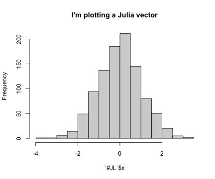

```julia
# x is in Julia workspace
x = randn(1000)

# $ is the interpolation operator
R"""
hist($x, main = "I'm plotting a Julia vector")
""";
```

```
┌ Warning: RCall.jl: Warning: `qplot()` was deprecated in ggplot2 3.4.0.
└ @ RCall ~/.julia/packages/RCall/0ggIQ/src/io.jl:172
┌ Warning: RCall.jl: `stat_bin()` using `bins = 30`. Pick better value with `binwidth`.
└ @ RCall ~/.julia/packages/RCall/0ggIQ/src/io.jl:172
```

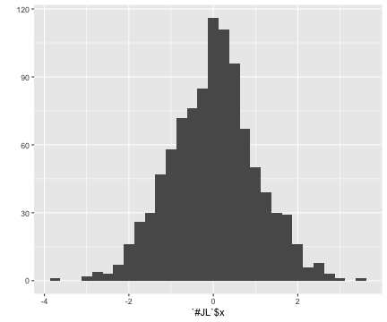

```
RObject{VecSxp}
```

```julia
R"""
library(ggplot2)

qplot($x)
"""
```

```julia
x = R"""
rnorm(10)
"""
```

```
RObject{RealSxp}
 [1]  0.7918257  0.2564399  0.3989598 -1.3428199  1.0601808  0.3390756
 [7] -0.4230867  0.3317554  0.8377051 -1.5231921
```

```julia
# collect R variable into Julia workspace
y = collect(x)
```

```
10-element Vector{Float64}:
  0.7918257099372811
  0.25643986812013725
  0.39895983958792663
 -1.3428198939562592
  1.0601808262352261
  0.33907555912946385
 -0.4230866721228354
  0.3317553994138106
  0.8377050969608829
 -1.5231920581399474
```

- Access Julia variables in R REPL mode:

```julia
julia> x = rand(5) # Julia variable
R> y <- $x
```

- Pass Julia expression in R REPL mode:

```julia
R> y <- $(rand(5))
```

- Put Julia variable into R environment:

```julia
julia> @rput x
R> x
```

- Get R variable into Julia environment:

```julia
R> r <- 2
Julia> @rget r
```

- If you want to call Julia within R, check out the [`JuliaCall`](https://non-contradiction.github.io/JuliaCall//index.html) package.